# Spatial Occupancy Patterns of the Endangered Northern Long‐Eared Bat in New England - De La Cruz - 2025 - Diversity and Distributions - Wiley Online Library

[figure not shown]

[Diversity and Distributions](https://onlinelibrary.wiley.com/journal/14724642)

[Volume 31, Issue 11](https://onlinelibrary.wiley.com/toc/14724642/2025/31/11) e70122

[figure not shown]

RESEARCH ARTICLE

Open Access

# Spatial Occupancy Patterns of the Endangered Northern Long-Eared Bat in New England

[Jesse L. De La Cruz](https://onlinelibrary.wiley.com/authored-by/De+La+Cruz/Jesse+L.),

[Sabrina M. Deeley](https://onlinelibrary.wiley.com/authored-by/Deeley/Sabrina+M.),

[Elizabeth A. Hunter](https://onlinelibrary.wiley.com/authored-by/Hunter/Elizabeth+A.),

[W. Mark Ford](https://onlinelibrary.wiley.com/authored-by/Ford/W.+Mark),

First published: 25 November 2025

https://doi.org/10.1111/ddi.70122

**Funding:** Financial support was provided by the Maine Department of Inland Fisheries and Wildlife (No. CT-09A-20220304*2005), the BSC Group Inc. (No. A5TQRY4Y for the Massachusetts Department of Transportation and No. AKDZ7YMI for the Massachusetts Department of Conservation and Recreation), the Vermont Department of Transportation (No. GR1674), the U.S. Geological Survey (No. G20AC00219), and the U.S. Fish and Wildlife Service (No. G22AC00514-00).

**Editor:** Juliano Sarmento Cabral

## ABSTRACT

### Aim

White-nose syndrome has caused severe declines in eastern North American cave bats, leading to the federal listing of the northern long-eared bat (*Myotis septentrionalis*) as endangered in the United States and Canada. This has heightened the importance of long-term monitoring to inform species status assessments. We employed a combination of long-term repeated and single-season acoustic survey data to assess the regional presence, spatial distribution, occupancy, and detection probability of northern long-eared bats.

### Location

New England, United States.

### Methods

We analysed acoustic data from 2357 detector sites, aggregated by year, using Bayesian single-species occupancy models. We investigated the influence of habitat characteristics, climatic variables, and year (2015–2022) on occupancy and the effects of weather conditions and survey month (May to August) on detection probability. Spatial random effects were included to address residual spatial autocorrelation, with a 1-km resolution chosen based on significant positive autocorrelation observed in a non-spatial model.

### Results

Occupancy was highest on steep, forested hillsides with minimal anthropogenic development, higher in warmer regions, particularly along coastlines and on offshore islands, and declined across survey years. Including a 1-km spatial random effect reduced residual autocorrelation and suggests northern long-eared bats utilise resources at small to medium landscape scales. Detection probability was highest earlier in the maternity season, but declined when monthly precipitation or temperature exceeded average conditions.

### Conclusions

Conservation efforts that focus on steep, forested hillsides in warmer regions with low anthropogenic development could be beneficial. Our analysis supports the use of spatial random effects at a 1-km<sup>2</sup> scale, highlighting the importance of survey designs that capture ecological variation at species-specific resolutions. Additionally, early-season acoustic surveys conducted during favourable weather conditions may improve monitoring effectiveness. Acoustic sampling and spatial occupancy modelling offer powerful tools for monitoring remnant populations of northern long-eared bats and guiding conservation practices.

## 1 Introduction

In temperate North America, bats are among the most imperilled mammalian taxa (Hammerson et al. 2017), undergoing multifaceted declines across species and geographic regions. Major contributing factors include day-roost loss, foraging and hibernation habitat alteration or loss (Frick et al. 2020), white-nose syndrome (WNS), caused by the fungal pathogen *Pseudogymnoascus destructans* (*Pd*; Hoyt et al. 2021), and the expansion of wind-energy development (Muthersbaugh et al. 2019a; True et al. 2021). As such, monitoring bats to assess population and distributional change metrics has become a conservation priority at local (Rodhouse et al. 2011; Nocera et al. 2019), regional (Neece et al. 2018; Deeley, Kalen, et al. 2021a), and national and international scales (Reichert et al. 2021). For biologists and land managers tasked with bat conservation in the northeastern United States, especially in the New England states (Figure 1), mapping the post-WNS distribution, monitoring occupancy trends, and estimating detection probability are high conservation priorities.

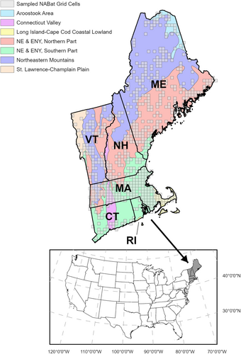

**FIGURE 1**

Open in figure viewer[PowerPoint](https://onlinelibrary.wiley.com/action/downloadFigures?id=ddi70122-fig-0001&partId=&doi=10.1111%2Fddi.70122)

Distribution of North American Bat Monitoring Program (NABat) grid cells acoustically surveyed for northern long-eared bats (*Myotis septentrionalis*) across six states (Connecticut [CT], Maine [ME], Massachusetts [MA], New Hampshire [NH], Rhode Island [RI], and Vermont [VT]) and seven major land resource areas (St. Lawrence-Champlain Plain, Northeastern Appalachian Mountains, both the Northern and Southern New England and Eastern New York (NE and ENY) Upland, Connecticut Valley, Aroostook Area, and Long Island-Cape Cod Coastal Lowland) of New England, United States, 2015–2022.

At local and regional scales (e.g., state or province), monitoring efforts for endangered species such as the northern long-eared bat (*Myotis septentrionalis*) and Indiana bat (*M. sodalis*) often rely on presence/probable absence data collected during surveys associated with planned or ongoing land management activities that could potentially impact day-roosting habitat or directly harm individuals (Sparks et al. 2009). For example, before the arrival of WNS, the U.S. Fish and Wildlife Service (USFWS) developed mist-netting survey protocols for assessing Indiana bat presence preceding land management actions (USFWS 1999). To address low mist-netting detection probability for Indiana bats following population declines from WNS, the USFWS developed acoustic-based presence/probable absence survey protocols (Britzke et al. 2002; Ford et al. 2023, 2024). Similarly, the North American Bat Monitoring Program (NABat) was established to collect, analyse, and share standardised data for large-scale monitoring of bat populations across North America (Loeb et al. 2015). While valuable for species-range level assessments, NABat surveys are conducted at a coarse spatial resolution (10-km<sup>2</sup>), contrasted with the 0.5-km<sup>2</sup> recommended for regulatory monitoring of Indiana and northern long-eared bats (USFWS 2023). Importantly, recent research has shown that northern long-eared bat habitat selection typically occurs at much finer spatial scales (< 2 km; Thalken et al. 2018), highlighting the limitations of broad-scale monitoring for informing fine-scale land management and reinforcing the continued need for targeted, site-specific research and monitoring.

Spatial autocorrelation, where observations in neighbouring geographic locations are correlated, can bias occupancy model estimates for highly mobile species such as North American bats by violating assumptions of independence (Browning et al. 2022). In occupancy modelling, spatial autocorrelation is often addressed by incorporating an autocovariate or spatial Gaussian process (SPG; Moore and Swihart 2005; Wright et al. 2021), approaches that can be adapted to species-specific ecological contexts. NABat addresses this in part by using a coarse-resolution sampling framework (Reichert et al. 2021), but such broad-scales may not align with the spatial ecology of some species. Identification of species-specific spatial dependencies and appropriate sampling resolutions can reduce ecological bias in regional occupancy models and improve detection of populations using distinct habitat types. For example, the limited migratory ability and small foraging and roosting ranges of northern long-eared bats require fine-scale data collection to better inform conservation and management (Badin 2014; De La Cruz et al. 2022; Ford, Silvis, Johnson, et al. 2016a; Hoff et al. 2024; Thalken et al. 2018; Silvis et al. 2014). Accurately accounting for these spatial dependencies is essential for producing reliable occupancy estimates and guiding effective conservation strategies for North American bats.

To assess the continued occurrence and inform monitoring strategies for northern long-eared bats in the post-WNS era across New England, during 2015–2022, we aimed to use passive acoustic monitoring data to: (1) identify presence of northern long-eared bats post-WNS; (2) evaluate the influence of cover type, climatic, and temporal variables on occupancy; (3) delineate the current distribution; (4) assess the effects of survey period and weather conditions on detection probability; (5) and determine spatial scale of ecological dependencies. We predicted that WNS-related population declines would result in limited presence observations at sampled sites during the study period. Based on prior research, we anticipated lower occupancy probabilities in fragmented landscapes, cooler regions, and areas affiliated with traditional hibernacula. We also predicted detection of northern long-eared bats would be highest during warmer, drier periods of the early maternity season. Finally, given their philopatry, small home ranges, and short foraging distances, we predicted that ecological dependencies related to acoustic data would be most evident at small to medium spatial resolutions. Our findings highlight the importance of habitat conservation at species-specific, ecologically relevant scales and seasonally targeted monitoring. We discuss how these results can guide effective management strategies to support northern long-eared bat conservation in the post-WNS landscape.

## 2 Methods

### 2.1 Study Species

The northern long-eared bat, historically abundant and widely distributed across temperate deciduous forests of eastern North America (Silvis et al. 2016), has suffered severe population declines (> 90%) following WNS emergence (Cheng et al. 2021). This subcontinental decline prompted its listing as endangered in Canada (COSEWIC 2013) and as threatened in 2015 (USFWS 2015), followed by uplisting to endangered in 2022, in the United States (USFWS 2022). While northern long-eared bats likely occupied > 70% of New England pre-WNS (Caceres and Barclay 2000), remnant maternity colonies are now largely restricted to coastal areas of Maine and Massachusetts, south to Long Island, New York (Dowling and O'Dell 2018; Gorman et al. 2023; Heilakka 2023; Hoff et al. 2024). Continued occupancy of these coastal sites may relate to a warmer, maritime-influenced climate, resulting in shorter hibernation periods and potentially reducing WNS-related mortality (Hoff et al. 2024). However, despite drastic declines, northern long-eared bats appear to persist at some inland mountain sites in New England, selecting for forested areas with wetlands (Reynolds et al. 2017; VanGorden 2017). Acoustic-based research has shown that northern long-eared bat activity is influenced by nightly weather conditions such as temperature, precipitation, and wind speed, which can affect species detection during surveys (Muthersbaugh et al. 2019b; Deeley, Kalen, et al. 2021c; Gorman et al. 2021; De La Cruz, Reynolds, et al. 2024b). Beyond these short-term fluctuations, seasonal reproductive stages also impact activity patterns, with recent observations indicating that peak acoustic activity occurs early in the maternity period prior to volancy (Gorman et al. 2022) and specifically during lactation (Deeley, Johnson, et al. 2021b). These ecological and behavioural characteristics underscore the importance of tailored monitoring approaches for assessing northern long-eared bat occupancy and guiding conservation, habitat management, and recovery strategies.

### 2.2 Study Area

Our study area comprised 621 NABat grid cells within six states and seven major land resource areas (MLRA) of New England (Figure 1). Acoustic sampling was conducted in the following states: Connecticut, Maine, Massachusetts, New Hampshire, Rhode Island, and Vermont. The MLRAs included: St. Lawrence-Champlain Plain, Northeastern Appalachian Mountains, both the Northern and Southern New England and Eastern New York (NE and ENY) Upland, Connecticut Valley, Aroostook Area, and Long Island-Cape Cod Coastal Lowland provinces (U.S. Department of Agriculture Natural Resources Conservation Service [USDA NRCS] 2022). These MLRAs represent the significant geographic and environmental variation present across the study area. Depending on MLRA, elevation ranged from sea level in the Northern and Southern NE and ENY Upland, Connecticut Valley, Aroostook Area, and Long Island-Cape Cod Coastal Lowland to above 1800 m in the Northeastern Appalachian Mountains. Similarly, both temperature and precipitation varied with MLRA. Mean annual temperature was lowest in the Northeastern Appalachian Mountains (−1°C–8°C) and warmest in the Long Island-Cape Cod Coastal Lowland (9°C–13°C), with mean total annual precipitation lowest in the St. Lawrence Plain (80–152 cm) and highest in the Northeastern Appalachian Mountains (85–235 cm; USDA NRCS 2022). Forest vegetation was generally classified as central hardwoods, containing an assemblage of oak (*Quercus* spp.)-hickory (*Carya* spp.), with an evergreen component of white pine (*Pinus strobus*) at lower elevations and latitudes, northern hardwoods comprised of American beech (*Fagus grandifolia*), birch (*Betula* spp.), sugar maple (*Acer saccharum*), hemlock (*Tsuga canadensis*), or spruce (*Picea* spp.)- balsam fir (*Abies* *balsamea*) dominated the more northern latitudes or at higher elevations throughout (USDA NRCS 2022).

### 2.3 Acoustic Analysis

We collated and analysed acoustic data collected by state, federal, and non-governmental organisations across New England during 2015–2022 (Figure 1; Objective 1). These data were provided through collaborative agreements and direct contributions with collecting partners. The resultant dataset (De La Cruz and Ford 2024) includes a combination of repeated long-term monitoring programs and non-random single-season clearance surveys, which are targeted surveys required by the USFWS to determine species presence or probable absence prior to development activities within the species' known range (USFWS 2023). Due to the opportunistic and multi-agency nature of the dataset, detailed metadata on detector type, deployment, and survey effort were not consistently available.

We used an automated acoustic software (Kaleidoscope Pro software; v. 5.4.7; Wildlife Acoustics, Maynard, MA) to identify echolocational recordings to species using default signal detection parameters and the 5.4.0 classifier set to ‘Balanced/Neutral’ (USFWS 2020). Given the potential for interspecific acoustic misclassification, it is necessary to identify community assemblages of bats to calculate a maximum likelihood estimator (MLE) statistic used to determine probable species presence or absence (Britzke et al. 2002; Ford et al. 2023, 2024). These species assemblages are predefined inputs to the MLE, which estimates the statistical probability of presence at the site-night scale. Species presence was accepted when the MLE returned a *p*-value less than 0.05, indicating statistical significance. Specific to each state, we examined the data for the presence of the following nine species: big brown bat (*Eptesicus fuscus*), eastern red bat (*Lasiurus borealis*), hoary bat (*L. cinereus*), silver-haired bat (*Lasionycteris noctivagans*), eastern small-footed bat (*M. leibii*), little brown bat (*M. lucifugus*), northern long-eared bat, Indiana bat, and tricolored bat (*Perimyotis subflavus*).

To reduce temporal autocorrelation, mitigate concerns regarding varying sampling effort, and allow for a clearer assessment of spatial occupancy patterns by reducing temporal variation, we aggregated nightly acoustic data by site, year, and month. Data were retained only for May through August, corresponding to the maternity season and period of assumed site-level closure within each year. We refer to closure as constant site-level occupancy within a season rather than demographic closure (e.g., no births or deaths) and did not assume closure across years. We used these detection/non-detections (i.e., observed monthly presence and/or probable absence) as the basis for all modelling efforts. This approach minimised the influence of revisits, emigration/immigration, and migration dynamics on our estimates (Straw et al. 2022). Additionally, we removed spatial duplicates, retaining within-year locations separated by > 100 m as unique points (Loeb et al. 2015). The final dataset comprised 2357 sites stacked by year, with each associated NABat grid cell sampled using an average of 2.4 (range: 1–15) acoustic locations, separated by an average distance of 1469 m, annually.

### 2.4 Cover Type, Temporal, and Weather Covariates

We examined northern long-eared bat occupancy in relation to percent deciduous forest cover and percent high-intensity development using the 2019 National Land Cover Dataset raster dataset (NLCD; Dewitz 2021; Objective 2). We calculated percentages for these cover types using a 0.5-km moving window analysis (Thalken et al. 2018; Cable et al. 2021), that approximates the day roost to foraging site dispersal distance of northern long-eared bats (Owen et al. 2003; Timpone et al. 2010; Pauli et al. 2015; Cable et al. 2021; De La Cruz et al. 2023), using the *focal* function of the *terra* package (Hijmans 2023) in R (v. 4.3.0; R Core Team 2023). Additionally, to create a distance to forest metrics, we used a forest/non-forest reclassification of NLCD data to assign areas within forest interiors positive values and non-forest areas further from the forest edge negative values using the *distance* function of *terra* (Hyzy et al. 2020; De La Cruz et al. 2023). Also using NLCD, we evaluated the relationship between northern long-eared bat occupancy and total landscape richness (i.e., maximum potential of 16 cover types within a 0.5-km window; De La Cruz et al. 2023). We also assessed occupancy in relation to 30-year (1991–2020) parameter-elevation regressions on independent slopes model (PRISM) normal mean annual temperature from the standard 4-km<sup>2</sup> PRISM grid cell (PRISM Climate Group 2021; Hoff 2023). Additionally, we examined the effect of landscape slope on northern long-eared bat occupancy (De La Cruz et al. 2023); measure of slope was calculated from 30-m digital elevation models (Gesch et al. 2002) using the *terrain* function of *terra*. We assessed variables for collinearity (threshold = |0.6|) using the *usdm* package (Naimi et al. 2014) of R before modelling. Finally, to determine if populations were still experiencing widespread WNS-induced declines, we assessed the linear effect of survey year (2015–2022) on northern long-eared bat occupancy. Specific to detection, we examined the linear effects of month of the survey season (May to August), total monthly precipitation (mm), and mean monthly temperature (°C). We obtained monthly PRISM precipitation and temperature data, also at a 4-km<sup>2</sup> resolution, using the *get_prism_monthlys* function of the package *prism* (Hart and Bell 2015) in R.

### 2.5 Occupancy Modelling and Distribution Mapping

Residual spatial autocorrelation is commonly addressed by incorporating site-level spatial information, i.e., site coordinates (Wright et al. 2021; Doser et al. 2022). To determine the optimal scale for modelling spatial dependencies in northern long-eared bat acoustic data collected during the maternity season, we first assessed residual spatial autocorrelation in a non-spatial occupancy model fit to the full dataset with all environmental covariates. We examined residuals using the *moran.mc* function of the *spdep* package of R (Bivand 2006; Fletcher and Fortin 2019), executing 999 permutations to evaluate statistical significance. By examining residuals across distances ranging from 100 m to 2000 m, we identified the spatial scale at which significant positive autocorrelation occurred (Objective 5). We subsequently used a 1-km<sup>2</sup> resolution indexing grid, nested within the 10-km<sup>2</sup> NABat grid, to align with the scale of spatial autocorrelation detected in the residuals and improve inference on occupancy predictors (Figure 5). Grid indexing allows for estimation of spatial random effects at the grid cell level, rather than for each individual site, by linking site observations to grid cell centroids. Consequently, sites within the same grid cell share a spatial random effect component, with full latent state estimations remaining site-specific.

We assessed model goodness-of-fit using posterior predictive checks, for both sites and replicates, employing Bayesian *p*-values derived from the Freeman-Tukey test statistic. Values near 0.5 indicated good fit and those < 0.1 or > 0.9 suggested poor fit (Gelman et al. 1996; Hobbs and Hooten 2015). Additionally, to evaluate model predictive performance on observed presence data, we used 5-fold cross-validation. Residuals were calculated as the difference between observed data and detection-modified occupancy predictions for each site in each test dataset (Moore and Swihart 2005). For each fold, to assess probabilistic accuracy, we calculated the mean squared error (MSE), i.e., Brier score, from these residuals. We further evaluated discriminative performance using the area under the receiver operating characteristic curve (AUC) based on the detection-modified occupancy predictions. We interpreted a Brier score of < 0.10 as excellent accuracy, 0.10–0.15 as good, 0.15–0.20 as acceptable, and > 0.20 as poor (Liu et al. 2009). We interpreted AUC values of 0.70–0.80 as fair, 0.80–0.90 as good, and 0.90–1.00 as excellent (Koma et al. 2022). We calculated model fit statistics (e.g., Freeman-Tukey, MSE, AUC) using each test dataset and averaged across the five folds.

We generated spatial occupancy predictions using widely applicable information criterion (WAIC) weights produced during cross-validation. Using spatial predictions, we mapped the potential occupancy distribution of northern long-eared bats across New England by applying the default 50% occupancy threshold to our spatial predictions, which is currently used by the USFWS for northern long-eared bat distribution models for regulatory purposes (USFWS 2024). This threshold reflects detection-corrected occupancy probabilities from our model, unlike traditional species distribution models that typically apply thresholds to naïve occurrence data without accounting for detection bias. However, to explore potential differences, we also mapped occupancy using a prevalence-based threshold, selected so that the proportion of predicted presences matched the observed prevalence in the test data (Freeman and Moisen 2008). This approach allowed us to assess how thresholding based on naïve presence data compares to detection-corrected probabilities and to evaluate its impact on spatial predictions.

## 3 Results

TABLE 1. Model fit statistics for occupancy and detection of northern long-eared bats (*Myotis septentrionalis*) in New England, USA, 2015–2022, based on 5-fold cross-validation. Values include site and replicate Bayesian *p*-values, expected log point-wise predictive density (elpd), effective number of parameters (pD), widely applicable information criterion (WAIC), ΔWAIC, mean squared error (MSE), and area under the receiver operating characteristic curve (AUC).

[output not shown]

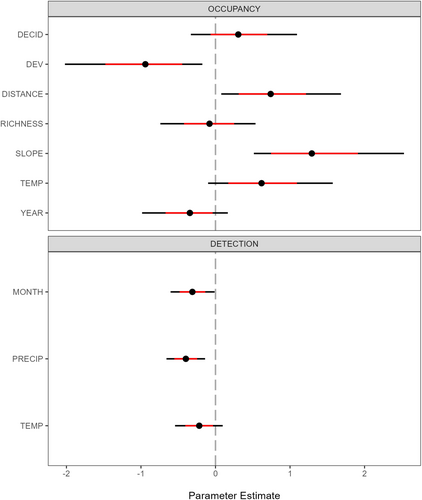

**FIGURE 2**

Open in figure viewer[PowerPoint](https://onlinelibrary.wiley.com/action/downloadFigures?id=ddi70122-fig-0002&partId=&doi=10.1111%2Fddi.70122)

Mean beta coefficients assessing northern long-eared bat (*Myotis septentrionalis*) occupancy and detection in New England, United States, 2015–2022. Black bars represent 95% Bayesian credible intervals (BCI), while red bars represent 75% BCIs. Occupancy covariates include: DECID (percent cover of deciduous forests), DEV (percent cover of high-intensity developed land), DISTANCE (distance into and away from forest relative to forest edge), RICHNESS (number of local cover types), SLOPE (degree of landscape slope), TEMP (average annual temperature), and YEAR (year of survey). Detection covariates include: MONTH (month of survey), PRECIP (total monthly precipitation), and TEMP (mean monthly temperature).

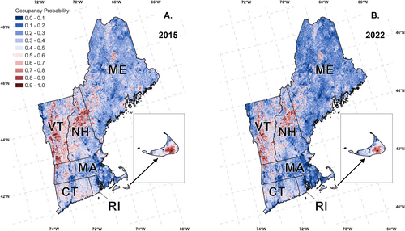

**FIGURE 3**

Open in figure viewer[PowerPoint](https://onlinelibrary.wiley.com/action/downloadFigures?id=ddi70122-fig-0003&partId=&doi=10.1111%2Fddi.70122)

Model-averaged predicted mean occupancy probability of northern long-eared bats (*Myotis septentrionalis*) in New England (Connecticut [CT], Maine [ME], Massachusetts [MA], New Hampshire [NH], Rhode Island [RI], and Vermont [VT]), United States, 2015 and 2022. Inset shows Nantucket Island, MA.

Spatially, occupancy probability appeared highest in the Northeastern Appalachian Mountains of Vermont and New Hampshire, along with the Northern NE and ENY Upland of Vermont, New Hampshire, and Maine, coastal portions of the Southern NE and ENY Upland in Connecticut, and the Long Island-Cape Cod Coastal Lowland of Massachusetts (Figure 3). Conversely, occupancy appeared lower in the Connecticut Valley of Connecticut and Massachusetts, the Southern NE and ENY Upland encompassing Rhode Island, Massachusetts, New Hampshire, and Maine, the Aroostook Area of Maine, and St. Lawrence-Champlain Valley of Vermont (Figure 3). Our analysis, using the default 50% threshold for 2022 predictions, suggested that northern long-eared bats occupied approximately 15% of New England, a decrease from 22% in 2015 (Figure 4). Alternatively, applying the prevalence-based threshold (*p* ≥ 0.59) indicated that the species may have occupied as little as 9% of New England by 2022, down from 13% in 2015 (Figure 4; Objective 3). Detection of northern long-eared bats was highest earlier in the maternity season, with strong support for reduced detection when within-month precipitation was above average and meaningful evidence for reduced detection when temperatures were above average (Figure 2; Objective 4). Our cross-validation model-averaged predictions indicated a detection probability of *ρ* = 0.44 (BCI = 0.35–0.55) under mean survey conditions.

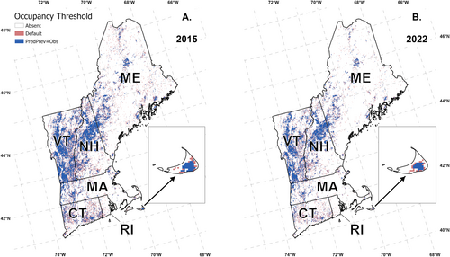

**FIGURE 4**

Open in figure viewer[PowerPoint](https://onlinelibrary.wiley.com/action/downloadFigures?id=ddi70122-fig-0004&partId=&doi=10.1111%2Fddi.70122)

Probable occupancy of northern long-eared bats (*Myotis septentrionalis*) in New England (Connecticut [CT], Maine [ME], Massachusetts [MA], New Hampshire [NH], Rhode Island [RI], and Vermont [VT]), United States, 2015 and 2022. Inset shows Nantucket Island, MA. Occupancy was mapped using two probability thresholds: The default 50% threshold (below the prevalence layer) and a predicted prevalence threshold (*p* ≥ 0.59) calibrated to observed prevalence in testing data.

From our assessment of spatial dependencies in residuals of a non-spatial occupancy model, we detected significant positive spatial autocorrelation at the 1-km scale (Figure 5). Our findings suggest that, based on acoustic data reflective of foraging and commuting behaviours, northern long-eared bats exhibit small to medium landscape-scale spatial dependencies. Consequently, we selected this scale for spatial indexing and included it as spatial random effects in all occupancy models fit during cross-validation to account for spatial structure regionally (Objective 5).

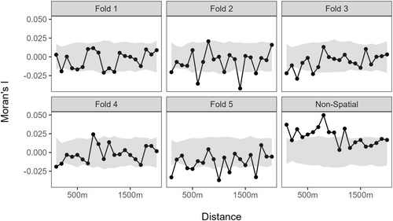

**FIGURE 5**

Open in figure viewer[PowerPoint](https://onlinelibrary.wiley.com/action/downloadFigures?id=ddi70122-fig-0005&partId=&doi=10.1111%2Fddi.70122)

Spatial correlograms of Moran's I values on residuals from spatial models fit within a 5-fold cross-validation framework (Folds 1–5) and a non-spatial model across varying distances (m); points outside the grey confidence band indicate significant spatial autocorrelation in northern long-eared bat (*Myotis septentrionalis*) occupancy and detection in New England, United States (2015–2022).

## 4 Discussion

Our research indicates that northern long-eared bats likely occur at a limited number of sites across New England, suggesting a patchy and declining regional distribution consistent with post-WNS era population declines (Objective 1). Regarding habitat influences, our regional model showed that northern long-eared bat occupancy was highest in interior forested areas on moderate to steep slopes, particularly in warmer regions (Objective 2). These findings align with the well-established view of the species as a forest obligate throughout its range (Silvis et al. 2016). Areas across New England containing greater forest cover and more rugged topography likely offer abundant and higher-quality roosting opportunities for bats. Such areas may promote roost formation and maternity colony establishment through increased natural disturbance regimes such as wind events, ice storms, and fire, and through greater solar exposure associated with southern and western aspects (Lorimer and White 2003; De La Cruz et al. 2018). We found that warmer temperatures were also positively associated with occupancy, consistent with recent documentation of remnant northern long-eared bat populations in coastal habitats within the region (Hoff et al. 2024).

However, remnant populations in some coastal and urban areas appear to persist in non-traditional habitats. Recent research has shown that northern long-eared bats occur in fragmented forest patches within dense residential development (Gorman et al. 2023), low stands of scrub oak (*Q. ilicifolia*) and mature pitch pine (*P. rigida*) interspersed with considerable anthropogenic development (Dowling and O'Dell 2018), and in large urban forest remnants (Thorne et al. 2021; Deeley et al. 2021a). Importantly, mist-netting surveys informed by a subset of our acoustic data resulted in captures of northern long-eared bats in coastal residential areas of Massachusetts (H. Larkin, Massachusetts Department of Conservation and Recreation, and C. Kalina, SWCA Environmental Consultants, oral presentation, Northeastern Bat Working Group, January 16, 2025), providing valuable ground-truthing for acoustic detections in this region. These occurrences suggest some degree of habitat flexibility, although such populations may be more vulnerable to anthropogenic stressors such as habitat loss and social disruption, particularly when combined with the pressures of WNS (Silvis et al. 2015; Garg et al. 2023). To delineate the current distribution of northern long-eared bats, we highlight the importance of conducting local and regional analyses to inform habitat conservation and management (Objective 3). Our model predicted highest occupancy across much of Vermont and New Hampshire, coastal Connecticut and Massachusetts, and parts of central and coastal Maine. Traditional species distribution models frequently rely on a fixed 50% probability threshold to delineate species presence. However, this approach can be unreliable, particularly for rare species (Freeman and Moisen 2008). Unlike traditional species distribution models, our northern long-eared bat occupancy model explicitly corrects for detection bias, and yet the 50% threshold may still overestimate the current distribution given the species' rapid decline in New England and the disconnect between occupancy estimates and abundance (Goodwin et al. 2024; Udell et al. 2025). For instance, we found that 15% of the region was likely occupied during 2022 using the 50% threshold, but during the same period a prevalence-based threshold yielded a more conservative 9% estimate. Applying a prevalence-based threshold, derived from naïve occupancy observed in testing data, may allow for a more conservative identification of areas of highest conservation value, whereas the 50% threshold may better represent the species' potential maximum range under current conditions.

Although we found that northern long-eared bat occupancy declined with increasing high-intensity development, the species has been observed to tolerate certain small-scale natural disturbances that create or maintain roosting opportunities. Previous studies have shown that bats may select roosts created by prescribed fire (Johnson et al. 2009; Silvis et al. 2012; Ford, Silvis, Johnson, et al. 2016a; Ford, Silvis, Rodrigue, et al. 2016b; Ford et al. 2021) or fluctuating water regimes (De La Cruz et al. 2022), indicating a reliance on dynamic forest conditions. Some individuals have also been documented roosting in anthropogenic structures and overwintering in human-modified environments in the Northeast (Dowling and O'Dell 2018; Hoff et al. 2024), suggesting behavioural flexibility related to hibernation. However, colony cohesion may weaken with excessive roost loss at the local scale within the roosting home range of a maternity colony (< 0.6 km<sup>2</sup>; Silvis et al. 2015). Given our observed negative responses to intense urbanisation, northern long-eared bats may be particularly susceptible to pressures such as systematic roost removal, habitat fragmentation, and reduced foraging habitat diversity and condition (Pourshoushtari et al. 2018; Korine et al. 2023). Surprisingly, our occupancy models did not detect associations with deciduous forest cover or landscape richness. However, it is likely that fine-scale forest structure and habitat heterogeneity, which were beyond the scope of our regional analysis, still are important for understanding where remnant populations persist in human-altered landscapes.

Consistent with others (Muthersbaugh et al. 2019b; Deeley, Kalen, et al. 2021c; De La Cruz, Reynolds, et al. 2024b), we found that seasonal timing and precipitation strongly influenced northern long-eared bat detection during the summer maternity season (Objective 4). This aligns with lactation and pup rearing (Deeley et al. 2022; De La Cruz, Kalen, et al. 2024a), and the increased energetic costs of foraging during precipitation (Voigt et al. 2011). A meaningful decline in detection later in the season, particularly under warmer than average within-month conditions, suggests reduced activity following peak maternity demands rather than an increase in detections associated with pup volancy (Ford et al. 2011). In populations severely impacted by WNS, climate and seasonal influences on detection may be compounded by failed colony cohesion and recruitment (Kalen et al. 2022; Francl et al. 2012). Despite WNS-driven declines (Cheng et al. 2021), maternity colonies remain relatively easier to monitor than dispersed post-volancy bats due to their aggregation and concentrated foraging activity (Ford et al. 2011). Our findings demonstrate the importance of recognising how climatic and seasonal dynamics shape detection and reinforce the need for spatially explicit, fine-scale monitoring and conservation strategies for northern long-eared bats across New England.

Importantly, we detected significant spatial autocorrelation in occupancy at the 1-km scale based on acoustic data, indicating likely clustered remnant populations at small to medium landscape scales (Objective 5). This pattern is consistent with known life history traits, including short-distance movements between diurnal roosts (Foster and Kurta 1999; Gumbert et al. 2002; Broders et al. 2006; O'Keefe 2009; Badin 2014; Silvis et al. 2015; Gorman et al. 2023), small maternity colony home ranges (Owen et al. 2003; Arant et al. 2022; De La Cruz et al. 2022), and foraging near roosts (Ford et al. 2006; Henderson and Broders 2008; Johnson et al. 2009; Krynak 2010). Additionally, short seasonal migration (Thalken et al. 2018; Hoff et al. 2024), strong site fidelity (Patriquin et al. 2013), and female philopatry (Arnold 2007; Johnson et al. 2015) further support fine-scale clustering. These spatially clustered areas of high occupancy may represent important population centers on the post-WNS landscape, where localised persistence could depend on conserving suitable, occupied habitat. Recognising that complete spatial independence in ecological data is often unrealistic and may obscure underlying processes, strategically incorporating spatial clustering into survey designs may improve habitat association analyses. Additionally, conducting targeted mist-netting surveys informed by acoustic detections, as demonstrated in coastal Massachusetts, may also aid in verifying presence and identifying active maternity sites. For northern long-eared bats, which exhibit scale-dependent roost-site selection and foraging behaviour influenced by both stand-level conditions and landscape structure, clustered sampling can help capture the spatial heterogeneity necessary to model multi-scale habitat use (Perry et al. 2008; Silvis et al. 2016; Thalken et al. 2018). Analyses conducted at coarse resolutions (> 1-km<sup>2</sup>) may fail to detect clustered populations or resolve key habitat associations. Misrepresenting this structure in surveys or models could result in false negatives or false positives, leading to unnecessary regulatory burdens or inefficient conservation planning.

Survival of some remnant populations of cave-hibernating bats impacted by WNS have shown signs of improvement since the early stages of the epidemic (Langwig et al. 2017; Cheng et al. 2019; Ineson 2020; Grimaudo et al. 2022). For example, little brown bat survival rates in New England have stabilised or even surpassed pre-WNS levels in some cases (Ineson 2020). Remnant populations of northern long-eared bats appear to persist in this region, with reproductive females captured several years after the onset of WNS (Dowling and O'Dell 2018; Gorman et al. 2023; Hoff et al. 2024). However, evidence of successful contemporary recruitment remains uncommon. Studies in the Central Appalachian Mountains observed reproductive females abandoning roosting early in the maternity season, with no juveniles detected, suggesting failed recruitment (Francl et al. 2012; Kalen et al. 2022). Importantly, our analysis suggests a continued, biologically informative decline in occupancy across New England and is consistent with broader patterns of regional decline following WNS emergence (Straw et al. 2022; Utrup 2022). Collectively, these findings may indicate some level of adult survival but severely reduced juvenile recruitment, a dynamic indicative of widespread functional extirpation. Although our occupancy models do not directly measure survival or reproduction, they provide critical insight into spatial patterns of presence and decline that are consistent with long-term population declines and distributional contraction.

## Author Contributions

Jesse L. De La Cruz, Sabrina M. Deeley and W. Mark Ford conceptualized the idea and developed the methodologies; Jesse L. De La Cruz and Elizabeth A. Hunter led data analysis and interpretation with assistance from Sabrina M. Deeley and W. Mark Ford; Jesse L. De La Cruz led on writing. All authors contributing to manuscript editing and final preparation.

## Acknowledgements

We thank Conservation Management Institute at Virginia Polytechnic and State University for assistance. We thank our state partners for data provision: the Connecticut Department of Energy and Environmental Protection, the Maine Department of Inland Fisheries and Wildlife, the Maine Department of Transportation, the Massachusetts Department of Conservation and Recreation, the Massachusetts Department of Fisheries and Wildlife, the Massachusetts Department of Transportation, the New Hampshire Division of Transportation, the New Hampshire Fish and Game Department, the Rhode Island Department of Environmental Management, and the Vermont Fish and Wildlife Department. We also thank our private industry collaborators for data provision and support: the BSC Group, Tetra Tech Inc., Stantec Inc., Normandeau Associates Inc., and Vanasse Hangen Brustlin Inc. Funding was provided by the U.S. Fish and Wildlife Service, U.S. Geological Survey, Maine Department of Inland Fisheries and Wildlife, Vermont Department of Transportation, and the BSC Group Inc. through cooperative agreements to Virginia Polytechnic Institute and State University.

## Ethics Statement

The authors have nothing to report.

## Consent

The authors have nothing to report.

## Conflicts of Interest

The authors declare no conflicts of interest. Any use of trade, firm or product name is used for descriptive purposes only and does not imply endorsement by the U.S. Government.

## Data Availability Statement

Data are available from the U.S. Geological Survey https://doi.org/10.5066/P135PJS5.

## References

[figure not shown]

[Volume31, Issue11](https://onlinelibrary.wiley.com/toc/14724642/2025/31/11)

November 2025

e70122

### Recommended

  [Marissa M. Thalken](https://onlinelibrary.wiley.com/authored-by/Thalken/Marissa+M.), [Michael J. Lacki](https://onlinelibrary.wiley.com/authored-by/Lacki/Michael+J.),

  [Diversity and Distributions](https://onlinelibrary.wiley.com/journal/14724642)

[Download PDF](https://onlinelibrary.wiley.com/doi/pdf/10.1111/ddi.70122)

back